# W03 — Losowość, estymacja i dwa tory wnioskowania

Zarządzanie informacją — część ilościowa — 2026/27

Marek Deja

2026/27

Wykład W03 przechodzi od wyniku jednej próby do opisu jego niepewności. Skrypt `analiza.R` zapisany w folderze wykładu liczy przykłady z podanych statystyk opisowych, tabele modeli rozkładów i symulacje; kod skryptu pozostaje ukryty. Symulacja jest modelem dydaktycznym: komputer losuje 2000 prób po 40 osób z populacji czasu o znanej średniej 10 minut i odchyleniu standardowym 4 minuty, więc wielkości niedostępne w jednej rzeczywistej próbie — rozkład średnich i pokrycie przedziałów — dają się policzyć. Każdy wykres ma w tekście słowny opis osi, wartości i wniosku.

# Jedna ankieta, cztery pytania

Biblioteka otrzymała podsumowanie oceny katalogu: średni indeks jest wyższy od środka skali. Jak duża jest różnica? Jak precyzyjnie ją oszacowano? Czy wynik tej wielkości byłby rzadki przy średniej równej wartości odniesienia? Czy wynik opisuje wszystkich użytkowników? Cztery pytania dotyczą wielkości, precyzji, zgodności z modelem zerowym i populacji.

Pierwsze pytanie dotyczy wielkości efektu w punktach, drugie — niepewności estymacji, trzecie — zgodności wyniku z modelem zerowym, a czwarte — populacji, doboru próby, odmów i pomiaru. Test statystyczny odpowiada na pytanie trzecie; pytania o wielkość, precyzję i populację wymagają efektu, przedziału i opisu doboru próby.

Ćwiczenie C04 (Od pozycji do konstruktu: samoocena i wykonanie zadania) ustaliło, że indeks S02 podsumowuje dydaktyczne pozycje deklarowanej użyteczności katalogu. Indeks zachowuje to znaczenie w całym wykładzie; wykład W03 dodaje do indeksu opis niepewności losowej. Symulacje ilustrują argument, a zadaniem studenta jest odczyt ich wyników.

# Cztery pojęcia estymacji

Cztery pojęcia estymacji

| Pojęcie | Znaczenie | Przykład |
| --- | --- | --- |
| Estymanda | Dokładnie określona wielkość, którą chcemy oszacować | Średni czas zadania w określonej populacji i warunkach |
| Parametr | Liczba charakteryzująca populację lub model | $\mu$, średnia czasu w populacji |
| Estymator | Reguła wykorzystująca dane do oszacowania | Średnia arytmetyczna z próby |
| Estymata | Konkretna otrzymana wartość | 11,2 minuty w danej próbie |

Parametr wybrany jako cel estymacji jest estymandą; słowo „estymanda” przypomina o określeniu populacji, wyniku, warunków i sposobu podsumowania. Średni czas wszystkich prób i średni czas prób zakończonych sukcesem to dwie estymandy, zapisywane literą $\mu$ z dwoma różnymi indeksami.

Statystyka jest funkcją danych z próby. Średnia, SD, odsetek i statystyka testowa t pełnią różne role: średnia szacuje parametr, SD opisuje rozrzut i wchodzi do oszacowania niepewności, a t odnosi różnicę do jej błędu standardowego. Efektem nazywa się statystykę opisującą wielkość różnicy lub związku; w przykładach W03 są to różnica $\widehat\Delta$ i standaryzowana różnica $d$.

## Populacja ma granice

Określenie „wszyscy użytkownicy informacji” obejmuje zbyt wiele sytuacji dla jednego zadania w katalogu. Precyzyjny cel dotyczy np. nowych użytkowników konkretnej usługi, wykonujących określone zadanie w danym okresie i na określonym urządzeniu. Zmiana populacji, zadania, okresu lub urządzenia zmienia rozkład wyników.

Uogólnienie wymaga powiązania sposobu doboru z populacją. Próba osób, które wypełniły ankietę po udanym wyszukaniu, reprezentuje osoby kończące wyszukiwanie sukcesem. Błąd standardowy opisuje zmienność losową, a obciążenie z samoselekcji pozostaje poza SE.

W danych syntetycznych kursu wnioskowanie jest ćwiczeniem procedury przy jawnych założeniach. Projekt indywidualny opisuje hipotetyczną populację i projekt oraz nazywa dydaktyczny charakter danych.

## Oznaczenia wykładu W03

Tabela „Oznaczenia wykładu W03” zbiera symbole wzorów wykładu; każdy symbol ma w tekście definicję w miejscu pierwszego użycia. Duża litera oznacza zmienną losową, a mała — zaobserwowaną wartość; litera $t$ jest zarezerwowana dla statystyki testu t.

Oznaczenia wykładu W03

| Symbol | Znaczenie |
| --- | --- |
| $X$, $x$; $K$, $k$ | Zmienna losowa i jej wartość (czas; liczba sukcesów) |
| $\pi$, $\binom{n}{k}$ | Prawdopodobieństwo sukcesu; liczba układów $k$ sukcesów w $n$ próbach |
| $f(x)$, $F(x)$ | Gęstość albo prawdopodobieństwo punktu; dystrybuanta $P(X\le x)$ |
| $\lambda$, $e$ | Intensywność kończenia zadań na minutę; liczba Eulera $e\approx2{,}718$ |
| $\mu$, $\sigma$, $Z$, $\Phi$, $z_p$ | Średnia i SD populacji; zmienna standaryzowana; dystrybuanta $N(0,1)$; kwantyl rzędu $p$ |
| $\bar{x}$, $s$, $n$, $SE$ | Średnia, SD i liczebność próby; błąd standardowy |
| $t$, $df$, $t_{p;\,df}$ | Statystyka t; stopnie swobody; kwantyl rzędu $p$ rozkładu t |
| $\mu_0$, $H_0$, $H_1$ | Wartość odniesienia; hipoteza zerowa i alternatywna |
| $\Delta$, $\widehat\Delta$, $d$ | Różnica w populacji; jej estymata; różnica w jednostkach SD osób |
| $p$, $\alpha$, $\beta$, $1-\beta$ | Wartość p; poziom istotności; prawdopodobieństwo błędu II rodzaju; moc |
| $B$, $T_{\mathrm{obs}}$, $T^*_b$, $\varepsilon_i$ | Liczba powtórzeń; statystyka z danych; statystyka powtórzenia $b$; znak $\pm1$ |

# Prawdopodobieństwo punktu, przedziału i kwantyl

Niepewność opisuje rozkład. Zmienna dyskretna przyjmuje wartości, które da się policzyć, np. liczbę sukcesów; zmienna ciągła, np. czas, przyjmuje wartości z przedziału. W obu przypadkach całe prawdopodobieństwo rozkładu wynosi 1: dla zmiennej dyskretnej jako suma prawdopodobieństw punktów, dla ciągłej jako pole pod krzywą gęstości (w matematyce: całka).

## Model dwumianowy

Trzy niezależne próby odnalezienia dokumentu mają każda prawdopodobieństwo sukcesu $\pi=0{,}5$, a zmienna $K$ liczy sukcesy. Model dwumianowy podaje prawdopodobieństwo dokładnie $k$ sukcesów w $n$ próbach:

$$P(K=k)=\binom{n}{k}\pi^k(1-\pi)^{n-k},\qquad \binom{n}{k}=\frac{n!}{k!\,(n-k)!}:\qquad P(K=2)=3\cdot0{,}5^2\cdot0{,}5=0{,}375 .$$

Symbol dwumianowy $\binom{n}{k}$ liczy układy $k$ sukcesów wśród $n$ prób: $\binom{3}{2}=3$ układy dwóch sukcesów to SSN, SNS i NSS. Potęgi opisują prawdopodobieństwo każdego układu. Model dwumianowy zakłada niezależne próby o równym prawdopodobieństwie sukcesu; próby jednej osoby łamią niezależność przez uczenie się.

Tabela „Model dwumianowy: trzy próby” podaje dla każdego $k$ prawdopodobieństwo punktu $P(K=k)$ i dystrybuantę $F(k)=P(K\le k)$, czyli sumę prawdopodobieństw do $k$ włącznie.

Model dwumianowy: trzy próby, π = 0,5

| Liczba sukcesów k | P(K = k) | F(k) = P(K ≤ k) |
| --- | --- | --- |
| 0 | 0,125 | 0,125 |
| 1 | 0,375 | 0,500 |
| 2 | 0,375 | 0,875 |
| 3 | 0,125 | 1,000 |

Dokładnie dwa sukcesy mają prawdopodobieństwo $3/8=0{,}375$, najwyżej dwa — $F(2)=7/8=0{,}875$, a co najmniej dwa — $1-F(1)=1/2$.

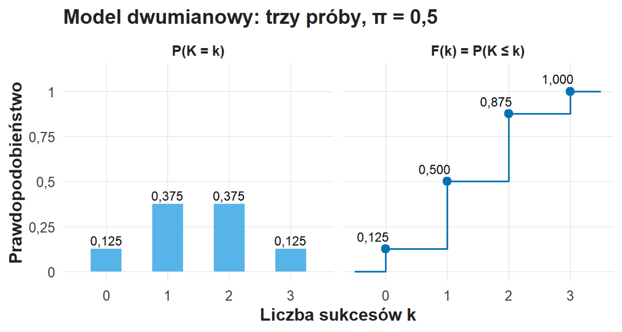

Model dwumianowy: trzy próby, π = 0,5. Lewy panel: słupki P(K = k) o wysokościach 0,125; 0,375; 0,375 i 0,125 dla k = 0, 1, 2, 3. Prawy panel: schodkowa dystrybuanta F(k) rośnie do 0,125; 0,500; 0,875 i 1,000.

## Model ciągły: pole pod krzywą gęstości

Dla zmiennej ciągłej prawdopodobieństwo przypisuje się przedziałom wartości. Prawdopodobieństwo przedziału równa się polu pod krzywą gęstości między granicami:

$$P(a<X\le b)=\int_a^b f(x)\,dx=F(b)-F(a).$$

Wyłącznie do demonstracji przyjmujemy model wykładniczy czasu z intensywnością $\lambda=0{,}1$ zakończenia na minutę, czyli średnią 10 minut:

$$f(x)=\lambda e^{-\lambda x},\qquad F(x)=1-e^{-\lambda x},\qquad x\ge0,\qquad \text{mediana}=\frac{\ln2}{\lambda}=6{,}93 \text{ minuty}.$$

Gęstość $f(5)=0{,}061$ na minutę opisuje wysokość krzywej przy 5 minutach; prawdopodobieństwo przedziału wynosi $P(5<X\le10)=F(10)-F(5)=0{,}239$. Tabela „Model wykładniczy czasu” podaje cztery wielkości modelu razem z wywołaniem R, które je liczy.

Model wykładniczy czasu, λ = 0,1 na minutę

| Wielkość | Wartość | Wywołanie R |
| --- | --- | --- |
| Gęstość f(5) [1/min] | 0,061 | dexp(5, 0.1) |
| F(5) = P(X ≤ 5) | 0,393 | pexp(5, 0.1) |
| P(5 < X ≤ 10) = F(10) − F(5) | 0,239 | pexp(10, 0.1) - pexp(5, 0.1) |
| Mediana: kwantyl rzędu 0,5 [min] | 6,931 | qexp(0.5, 0.1) |

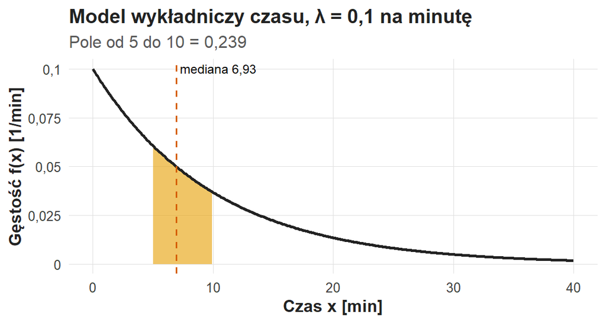

Model wykładniczy czasu, λ = 0,1 na minutę. Oś pozioma: czas x w minutach od 0 do 40; oś pionowa: gęstość na minutę. Krzywa maleje od 0,1 przy zerze; wyróżnione pole między 5 a 10 minutami wynosi 0,239; linia przerywana mediany przy 6,93 minuty dzieli całe pole na dwie równe części.

Mediana 6,93 minuty jest mniejsza od średniej 10 minut, bo model ma prawy ogon. Model wykładniczy ma własność braku pamięci: $P(X>5+x\mid X>5)=P(X>x)$, więc po 5 minutach szukania szansa na co najmniej kolejne 5 minut wynosi $e^{-0{,}5}=0{,}607$, tyle samo co na starcie. Złożone wyszukiwanie ma inną własność — dłuższe szukanie zbliża do końca — więc symulacja wykładu używa modelu log-normalnego.

W dokumentacji R prefiks `d` oznacza gęstość lub prawdopodobieństwo punktu, `p` — dystrybuantę, `q` — kwantyl, a `r` — losowanie. Zadania korzystają z gotowych wywołań; znajomość prefiksów pomaga czytać wynik. Tabela „Prefiksy funkcji rozkładów w R” podaje siedem przykładów użytych w wykładach W03 i W04.

Prefiksy funkcji rozkładów w R

| Wywołanie R | Prefiks | Wynik |
| --- | --- | --- |
| dexp(5, 0.1) | d: gęstość | 0,061 |
| pexp(5, 0.1) | p: dystrybuanta | 0,393 |
| qexp(0.5, 0.1) | q: kwantyl | 6,931 |
| pnorm(1.96) | p: dystrybuanta | 0,975 |
| qnorm(0.975) | q: kwantyl | 1,960 |
| qt(0.975, 15) | q: kwantyl | 2,131 |
| pchisq(3.84, 1) | p: dystrybuanta | 0,950 |

# Rozkład normalny i standaryzacja

Rozkład normalny opisuje zmienną, której wartości skupiają się symetrycznie wokół średniej $\mu$ z odchyleniem standardowym $\sigma$. Gęstość rozkładu normalnego i standaryzacja mają postać:

$$\varphi(x)=\frac{1}{\sigma\sqrt{2\pi}}\exp\!\left(-\frac{(x-\mu)^2}{2\sigma^2}\right),\qquad Z=\frac{X-\mu}{\sigma}\sim N(0,1).$$

Standaryzacja wyraża wartość jako odległość od średniej w jednostkach SD, więc zmienna $Z$ ma średnią 0 i SD 1; dystrybuantę rozkładu $N(0,1)$ oznacza się $\Phi$. W rozkładzie normalnym przedział $\mu\pm\sigma$ obejmuje 68,3% pola, $\mu\pm2\sigma$ — 95,4%, a $\mu\pm3\sigma$ — 99,7%. Kwantyl $z_{0{,}975}=1{,}96$ wyznacza środkowe 95% pola: $P(-1{,}96\le Z\le1{,}96)=0{,}95$.

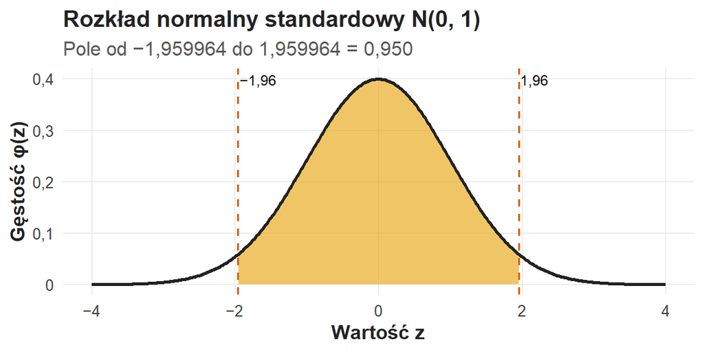

Rozkład normalny standardowy N(0, 1). Oś pozioma: wartość z od −4 do 4; oś pionowa: gęstość. Krzywa jest symetryczna wokół zera ze szczytem 0,40; wyróżnione pole między liniami przerywanymi przy −1,96 i 1,96 wynosi 0,950.

## Rozkład empiryczny i rozkład estymowany

Rozkład empiryczny to rozkład wartości zaobserwowanych w próbie; rozkład estymowany to model teoretyczny z parametrami oszacowanymi z próby. Rozkład log-normalny opisuje dodatnią zmienną, której logarytm ma rozkład normalny:

$$\ln X\sim N(\mu_{\ln},\sigma^2_{\ln}),\qquad
\sigma_{\ln}=\sqrt{\ln\!\left(1+\left(\tfrac{4}{10}\right)^2\right)}=0{,}385,\qquad
\mu_{\ln}=\ln10-\frac{\sigma_{\ln}^2}{2}=2{,}229 .$$

Parametry $\sigma_{\ln}$ i $\mu_{\ln}$ dobrano tak, aby populacja symulacji miała średnią 10 i SD 4 minuty. Jedna wylosowana próba 40 osób ma średnią 9,43, SD 4,28 i czasy od 4,0 do 22,9 minuty. Wykres „Rozkład empiryczny i dwa modele: dystrybuanty” zestawia schodki dystrybuanty empirycznej z dystrybuantami dwóch modeli dopasowanych do próby: normalnego o średniej 9,43 i SD 4,28 minuty oraz log-normalnego o średniej i SD logarytmów 2,16 i 0,42.

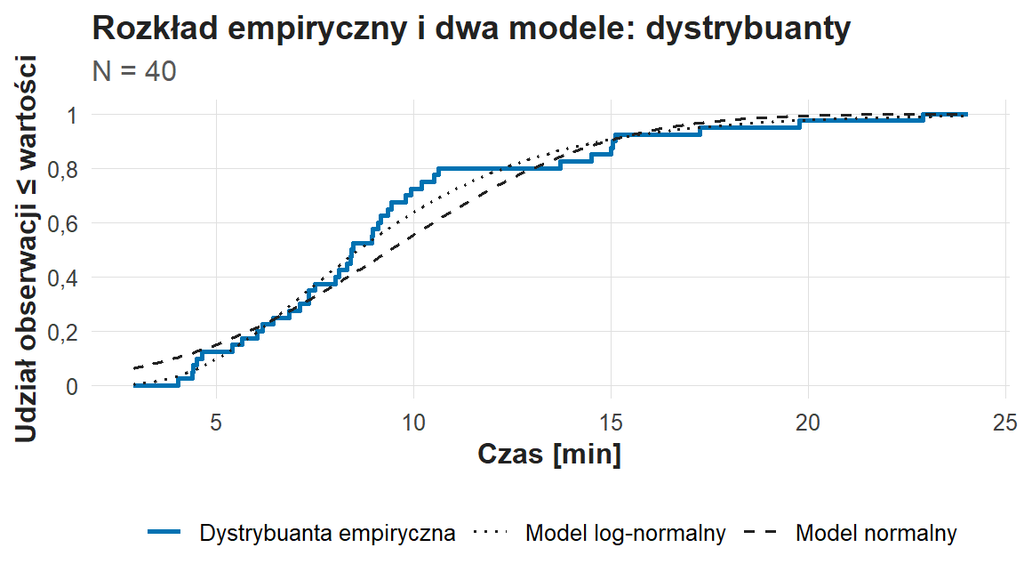

Rozkład empiryczny i dwa modele: dystrybuanty jednej próby 40 osób. Oś pozioma: czas w minutach; oś pionowa: udział obserwacji mniejszych lub równych wartości. Schodki (linia ciągła) rosną o 1/40 przy każdej obserwacji. Przy 10 minutach schodki osiągają 0,725, model log-normalny (linia kropkowana) 0,637, a normalny (linia przerywana) 0,553; przy 20 minutach schodki 0,975, log-normalny 0,977, normalny 0,993.

Tabela „Dystrybuanta empiryczna i dwa modele” podaje wartości trzech krzywych przy czterech progach. Model log-normalny leży bliżej schodków w prawym ogonie, a model normalny przypisuje czasom ujemnym 1,4% prawdopodobieństwa, choć czas jest nieujemny.

Dystrybuanta empiryczna i dwa modele przy czterech progach

| Próg c [min] | Dystrybuanta empiryczna | Model normalny | Model log-normalny |
| --- | --- | --- | --- |
| 5 | 0,125 | 0,150 | 0,097 |
| 10 | 0,725 | 0,553 | 0,637 |
| 15 | 0,850 | 0,904 | 0,906 |
| 20 | 0,975 | 0,993 | 0,977 |

Wykres „Rozkład empiryczny i dwa modele: gęstości” przedstawia tę samą próbę jako histogram gęstości z krzywymi obu modeli.

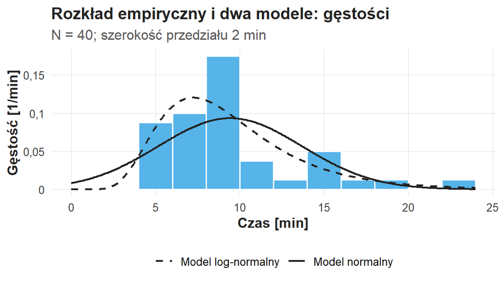

Rozkład empiryczny i dwa modele: gęstości jednej próby 40 osób. Oś pozioma: czas w minutach; oś pionowa: gęstość na minutę; przedziały po 2 minuty. Najwyższy słupek, 14 osób, stoi nad przedziałem od 8 do 10 minut. Krzywa normalna (ciągła) jest symetryczna wokół 9,43 minuty i sięga poniżej zera; krzywa log-normalna (przerywana) zaczyna się od zera, ma szczyt przy około 7,2 minuty i prawy ogon do ponad 20 minut.

Porównanie rozkładu empirycznego z estymowanym ocenia, czy model opisuje dane; wybór modelu rozkładu opiera się ponadto na analizie sposobu powstawania danych: czas jest dodatni i ma rzadkie długie próby.

# Rozkład osób i rozkład estymatora

W jednej próbie osoby mają różne czasy. Kolejne próby pobrane z tej samej populacji według tej samej procedury mają różne średnie. Zróżnicowanie czasów osób i zróżnicowanie średnich między próbami to dwie wielkości.

Wykres „Rozrzut osób i rozrzut średnich” ma dwa panele ze wspólną osią w minutach. Górny panel to histogram czasów 40 osób z jednej próby, a dolny — histogram średnich z 2000 prób po 40 osób; w dolnym panelu każda wartość reprezentuje całą próbę. Linia kropkowana w obu panelach oznacza średnią populacji $\mu=10$ minut, w zwykłym badaniu nieznaną.

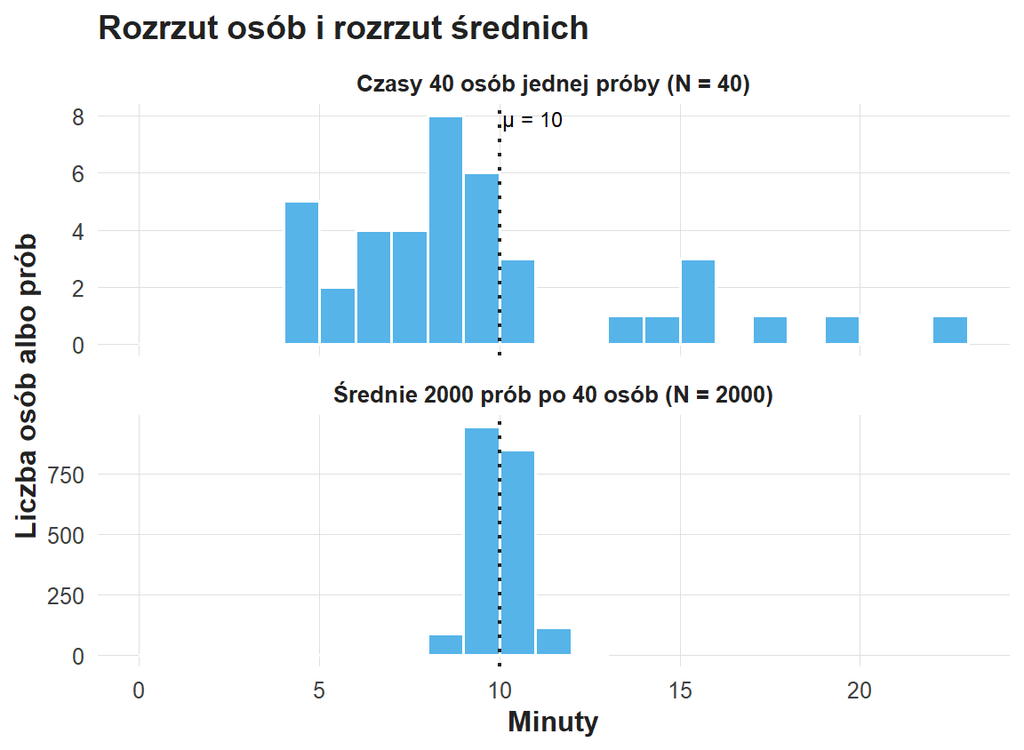

Rozrzut osób i rozrzut średnich. Oś pozioma: minuty; przedziały po 1 minucie; linia kropkowana przy 10 minutach. Górny panel: czasy 40 osób jednej próby leżą od 4,0 do 22,9 minuty. Dolny panel: średnie 2000 prób po 40 osób leżą od 8,1 do 12,4 minuty i skupiają się wokół 10 minut.

SD średnich wynosi 0,635 minuty, a SD czasów osób w populacji 4 minuty; iloraz $4/0,635\approx6{,}3$ jest bliski $\sqrt{40}=6{,}32$. Średnia wielu niezależnych obserwacji waha się mniej niż pojedyncza obserwacja.

## Centralne twierdzenie graniczne

Centralne twierdzenie graniczne opisuje rozkład średniej z $n$ niezależnych obserwacji o średniej $\mu$ i skończonym SD $\sigma$:

$$\bar{X}\approx N\!\left(\mu,\frac{\sigma^2}{n}\right),\qquad Z=\frac{\bar{X}-\mu}{\sigma/\sqrt{n}}\approx N(0,1).$$

Twierdzenie dotyczy rozkładu średniej: rozkład pojedynczych czasów zachowuje kształt przy każdym $n$. Zastąpienie nieznanego $\sigma$ przez SD próby $s$ daje statystykę t o $n-1$ stopniach swobody, na której opiera się przedział ufności. Wykres „Rozkład średniej przy rosnącym n” przedstawia 2000 średnich dla trzech liczebności.

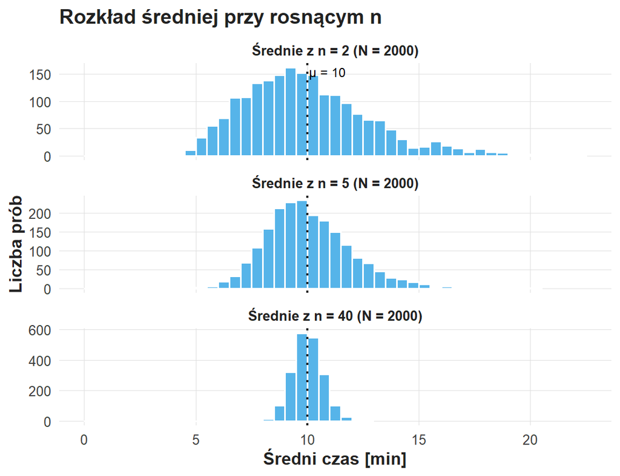

Rozkład średniej przy rosnącym n: histogramy 2000 średnich z populacji log-normalnej (przedziały po 0,5 minuty, linia kropkowana przy μ = 10). Przy n = 2 średnie leżą od 4,0 do 22,4 minuty z prawym ogonem (SD 2,79, skośność 0,79); przy n = 5 od 5,2 do 20,2 minuty (SD 1,87, skośność 0,63); przy n = 40 od 7,7 do 12,7 minuty, niemal symetrycznie wokół 10 minut (SD 0,65, skośność 0,20).

Liczebność potrzebna do dobrego przybliżenia normalnego rośnie ze skośnością danych i z zależnością obserwacji. Przy $n=40$ skośność średnich spada do 0,20, a SD średnich, 0,65 minuty, odpowiada wartości modelowej $4/\sqrt{40}=0{,}63$.

## Błąd standardowy jest odchyleniem standardowym estymatora

Dla niezależnych obserwacji o wspólnej skończonej wariancji błąd standardowy średniej szacuje się wzorem:

$$SE(\bar{x})=\frac{s}{\sqrt{n}}:\qquad \frac{4}{\sqrt{40}}=0{,}632 \text{ minuty wobec SD 2000 średnich } 0,635 \text{ minuty}.$$

Licznik opisuje zróżnicowanie osób, mianownik — ilość niezależnej informacji. SE ma jednostkę średniej: dla SD równego 4 minuty i $n=100$ błąd standardowy wynosi $4/\sqrt{100}=4/10=0{,}4$ minuty. Tabela „SE przy stałym SD” podaje SE równe 0,8; 0,4 i 0,2 minuty dla N = 25, 100 i 400 przy SD = 4 minuty; zależność zakłada stałe SD.

SE przy stałym SD równym 4 minuty

| Liczba osób N | SD [min] | SE = SD/√N [min] |
| --- | --- | --- |
| 25 | 4,0 | 0,8 |
| 100 | 4,0 | 0,4 |
| 400 | 4,0 | 0,2 |

Czterokrotnie większa liczebność daje dwukrotnie mniejsze SE przy niezmienionym SD. Osiemdziesiąt kliknięć jednej osoby wnosi informację o jednej osobie. Obserwacje powiązane wymagają procedury uwzględniającej zależność: uśrednienia wyników osoby przed analizą (jeden wynik na osobę, jak w wykładzie W01) albo modelu wielopoziomowego. W rozszerzeniu efektywną liczebność opisuje wzór

$$n_{\mathrm{ef}}=\frac{n}{1+(m-1)\rho}:\qquad \frac{80}{1+3\cdot0{,}3}=42{,}1,$$

gdzie $m$ to liczba obserwacji na osobę, a $\rho$ — korelacja wyników tej samej osoby; 80 pomiarów 20 osób po 4 zadania przy $\rho=0{,}3$ niesie informację równą 42 niezależnym pomiarom.

## Nieobciążoność, precyzja i zgodność

Estymator nieobciążony ma średnią estymat w wielu próbach równą parametrowi; pojedyncze estymaty rozrzucają się wokół parametru. Precyzja oznacza mały rozrzut estymat, a zgodność — zbliżanie się estymat do parametru wraz ze wzrostem liczebności. Obciążenie i błąd średniokwadratowy łączą dwie własności:

$$\text{obciążenie}=E(\hat\theta)-\theta,\qquad MSE=\text{obciążenie}^2+SE^2 ,$$

gdzie $\theta$ to parametr, a $\hat\theta$ — estymator. Ankieta 2000 najbardziej aktywnych użytkowników, szybszych od ogółu, ma średnią 8,5 minuty wobec 10 minut wszystkich użytkowników: obciążenie wynosi −1,5 minuty, SE przy SD 4 minuty tylko $4/\sqrt{2000}=0{,}09$ minuty, a $MSE=2{,}25+0{,}008=2{,}258$. Duża próba zmniejsza SE, a obciążenie pozostaje.

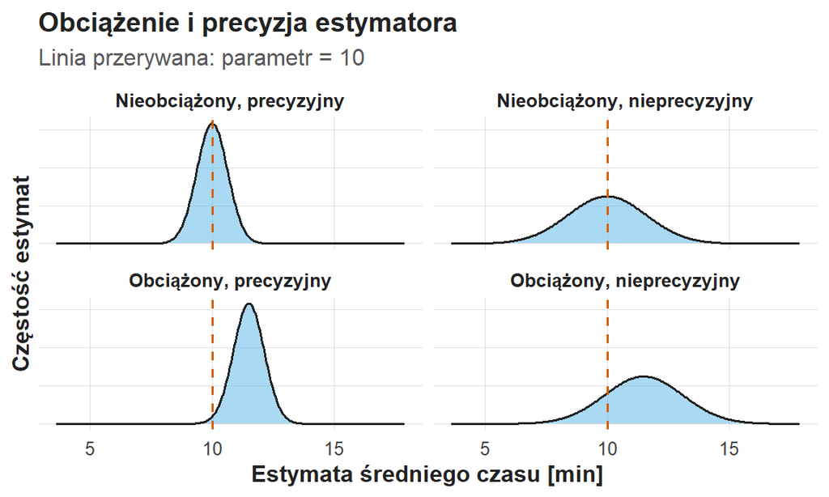

Obciążenie i precyzja estymatora: cztery rozkłady estymat średniego czasu, linia przerywana przy parametrze 10 minut. Górny lewy panel: wąski rozkład ze środkiem w 10 (nieobciążony, precyzyjny). Górny prawy: szeroki rozkład ze środkiem w 10. Dolny lewy: wąski rozkład ze środkiem w 11,5, w całości na prawo od parametru (obciążony, precyzyjny). Dolny prawy: szeroki rozkład ze środkiem w 11,5.

Interpretacja estymaty odpowiada na dwa pytania: „jak bardzo waha się oszacowanie?” i „czy procedura kieruje do właściwej wielkości?”. Wąski przedział odpowiada na pierwsze pytanie w ramach przyjętego modelu; drugie pytanie wymaga oceny doboru i pomiaru.

# Przedział ufności jako procedura

Przedział ufności średniej korzysta z kwantyli rozkładu t. Rozkład t ma grubsze ogony od rozkładu normalnego, a różnica maleje ze wzrostem liczby stopni swobody: kwantyl rzędu 0,975 wynosi 3,182 dla $df=3$, 2,131 dla 15, 2,023 dla 39, 1,984 dla 99 i 1,960 dla rozkładu normalnego.

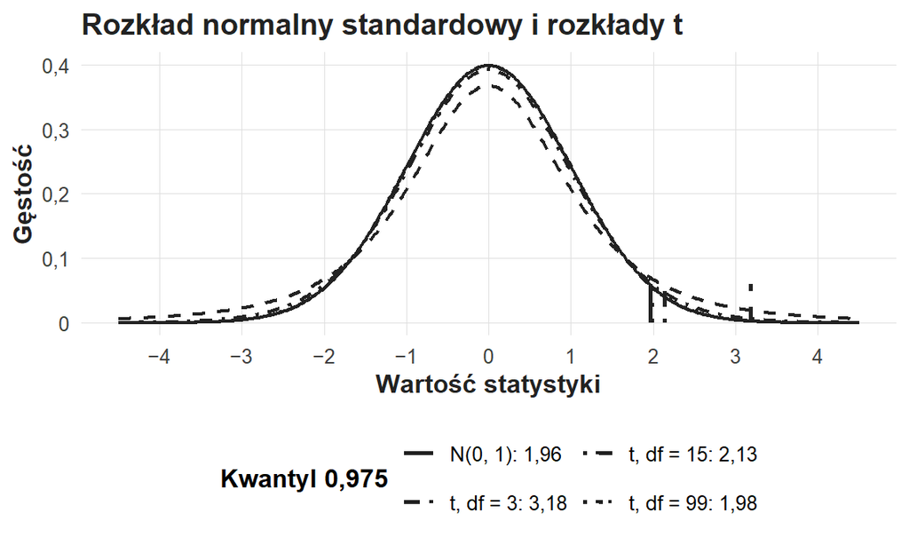

Rozkład normalny standardowy i rozkłady t. Oś pozioma: wartość statystyki od −4,5 do 4,5; oś pionowa: gęstość. Wszystkie krzywe są symetryczne wokół zera. Krzywa t z 3 stopniami swobody ma najniższy szczyt i najgrubsze ogony, a jej kwantyl 0,975 wynosi 3,18; krzywe t z 15 i 99 stopniami mają kwantyle 2,13 i 1,98, a rozkład normalny 1,96. Krótkie kreski przy osi oznaczają położenie kwantyli.

Dla średniej w standardowym modelu t dwustronny przedział 95% ma postać:

$$\bar{x}\ \pm\ t_{0{,}975;\,n-1}\,\frac{s}{\sqrt{n}} .$$

W środku przedziału leży estymata. Margines powstaje przez pomnożenie SE przez kwantyl rozkładu t o $n-1$ stopniach swobody; przy małej próbie kwantyl jest większy. Poziom 99% wymaga szerszego przedziału przy tych samych danych.

Poziom ufności opisuje długookresowe działanie procedury: przy spełnieniu warunków 95% tak konstruowanych przedziałów obejmuje ustalony parametr. Konkretny przedział obejmuje parametr albo go pomija; o konkretnym przedziale wiemy, jaką procedurą powstał.

Wykres „40 przedziałów z powtarzanych prób” przedstawia pierwsze 40 przedziałów z symulacji. Oś pozioma to średni czas w minutach, a oś pionowa — numer próby od 1 do 40. Każdy poziomy odcinek to przedział 95% jednej próby, punkt na odcinku to jej średnia, a pionowa linia kropkowana — parametr 10 minut.

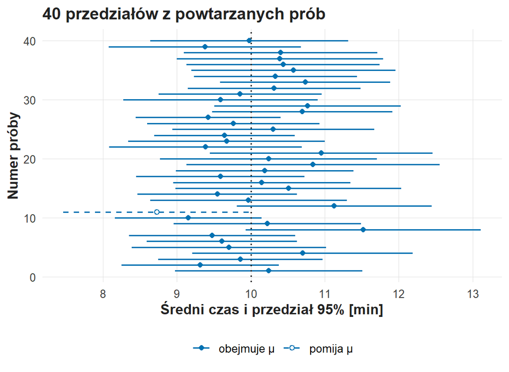

40 przedziałów z powtarzanych prób. Oś pozioma: średni czas i przedział 95% w minutach; oś pionowa: numer próby. 39 odcinków (linia ciągła, punkt pełny) przecina linię parametru przy 10 minutach; jeden odcinek, próba 11 (linia przerywana, punkt pusty), leży w całości na lewo od parametru.

Liczba przedziałów pomijających parametr w serii 40 prób jest losowa: przy pokryciu 95% ma rozkład dwumianowy z $n=40$ i $\pi=0{,}05$, średnio 2 pominięcia, a od 0 do 4 pominięć zdarza się w 95% serii. W przedstawionej serii jeden przedział pomija parametr. Populacja czasu jest skośna, więc przedział t ma uzasadnienie przybliżone.

Tabela „Podsumowanie 2000 prób” obejmuje wszystkie 2000 prób: średnia estymat wynosi 10,00 minuty, SD estymat 0,635 minuty, a pokrycie 94,35%. Liczebność próby wynosi 40; liczba 2000 to liczba powtórzeń eksperymentu komputerowego.

Podsumowanie 2000 prób po 40 osób

| Wielkość | Wartość |
| --- | --- |
| Liczba prób | 2000 |
| Osoby w próbie | 40 |
| Parametr μ [min] | 10 |
| Średnia 2000 estymat [min] | 10,00 |
| SD 2000 estymat [min] | 0,635 |
| SE z modelu: 4/√40 [min] | 0,632 |
| Przedziały obejmujące μ [%] | 94,35 |

## Trzy przedziały jednej próby

Jedna próba 40 osób daje trzy różne przedziały, które odpowiadają na trzy pytania:

$$\bar{x}\pm t_{0{,}975;\,n-1}\frac{s}{\sqrt{n}},\qquad
\bar{x}\pm t_{0{,}975;\,n-1}\,s\sqrt{1+\frac{1}{n}},\qquad
\left[Q(0{,}025);\ Q(0{,}975)\right].$$

Pierwszy to przedział ufności średniej populacji, drugi — przedział predykcji czasu jednej nowej osoby, a trzeci — zakres środkowych 95% zaobserwowanych czasów. Dla próby o średniej 9,43 i SD 4,28 minuty przedział ufności średniej jest najwęższy.

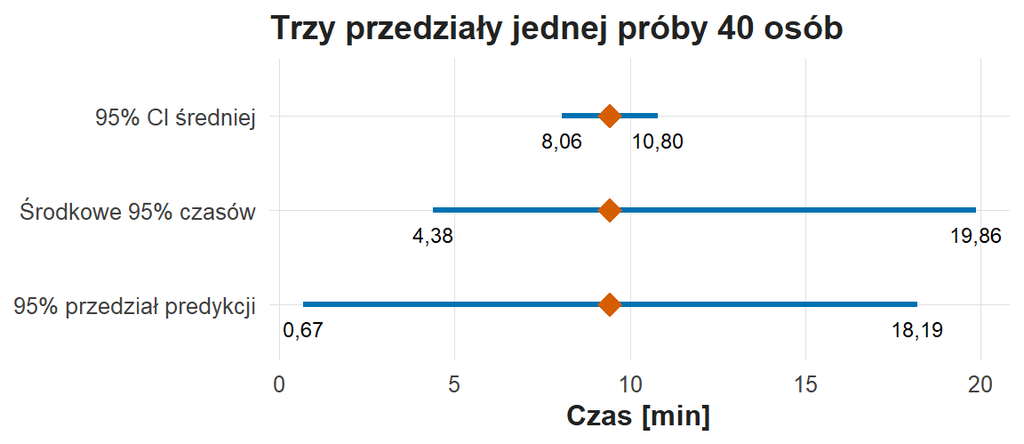

Trzy przedziały jednej próby 40 osób na wspólnej osi czasu, romb przy średniej 9,43 minuty. 95% przedział ufności średniej: od 8,06 do 10,80 minuty. Środkowe 95% czasów: od 4,38 do 19,86 minuty. 95% przedział predykcji czasu nowej osoby: od 0,67 do 18,19 minuty.

Przedział ufności średniej zwęża się ze wzrostem $n$, a przedział predykcji i zakres środkowych 95% czasów zależą głównie od zróżnicowania osób. W dużej próbie średnia jest oszacowana dokładnie, a ludzie nadal różnią się czasem.

# Przykład pierwszy: indeks względem środka skali

Osobny, hipotetyczny opis próby podaje: N = 100, średni indeks 3,24 i SD = 0,80 punktu. Wartość odniesienia 3 to środek skali odpowiedzi 1–5, przyjęty umownie jako punkt odniesienia.

Estymandą jest $\Delta=\mu-3$, różnica średniej określonej populacji od punktu odniesienia. Estymata wynosi $\widehat\Delta=3{,}24-3=0{,}24$ punktu. Wartość dodatnia oznacza średnią przesuniętą w stronę korzystnej oceny.

## Statystyka t jako odległość w jednostkach niepewności

$$t=\frac{\bar{x}-\mu_0}{s/\sqrt n}
=\frac{3{,}24-3}{0{,}80/\sqrt{100}}=\frac{0{,}24}{0{,}08}=3 .$$

Licznik to efekt w punktach, mianownik — SE średniej w punktach, więc jednostki się skracają. Statystyka $t=3$ oznacza, że estymata leży trzy oszacowane błędy standardowe powyżej wartości z hipotezy zerowej; trzy błędy standardowe to $3\cdot0{,}08=0{,}24$ punktu.

Hipoteza zerowa brzmi $H_0:\mu=3$, a dwustronna alternatywa $H_1:\mu\neq3$. Rozkład t z 99 stopniami swobody jest rozkładem odniesienia w klasycznym modelu. Przy niezależnych obserwacjach z rozkładu normalnego uzasadnienie jest dokładne; przy innych rozkładach stosowanie rozkładu t do średniej wymaga oceny przybliżenia, skrajności danych i liczebności.

Tabela „Przykład indeksu: składniki obliczenia” zawiera N = 100, średnią 3,24, SD 0,80, SE 0,080, różnicę 0,24, dwa przedziały 95% — średniej i różnicy — oraz t = 3,00, df = 99, p = 0,0034 i d = 0,30. Przesunięcie obu końców przedziału o 3 zmienia parametr opisywany przez przedział.

Przykład indeksu: składniki obliczenia

| Wielkość | Wartość | Jednostka |
| --- | --- | --- |
| Liczba osób N | 100 | osoby |
| Średnia | 3,24 | punkty |
| SD osób | 0,80 | punkty |
| SE średniej | 0,080 | punkty |
| Wartość odniesienia | 3,00 | punkty |
| Różnica od odniesienia | 0,24 | punkty |
| 95% CI średniej | [3,081; 3,399] | punkty |
| 95% CI różnicy | [0,081; 0,399] | punkty |
| Statystyka t | 3,00 | bez jednostki |
| Stopnie swobody df | 99 | bez jednostki |
| Wartość p (dwustronna) | 0,0034 | prawdopodobieństwo |
| Standaryzowana różnica d | 0,30 | SD osób |

Średnia 3,24 ma 95% CI [3,081; 3,399], a różnica 0,24 ma 95% CI [0,081; 0,399] punktu. Przedział średniej i przedział różnicy przekazują zgodną informację i odnoszą się do różnych wartości zerowych: 3 dla średniej i 0 dla różnicy. Efekt 0,24 punktu raportuje się z przedziałem różnicy [0,081; 0,399].

## Wartość p jest warunkową oceną skrajności

Dwustronna wartość p jest prawdopodobieństwem warunkowym otrzymania statystyki co najmniej tak skrajnej jak obserwowana, w obu kierunkach; warunkiem jest prawdziwość $H_0$ i założeń modelu:

$$p=P\left(|T|\ge|t_{\mathrm{obs}}|\;\middle|\;H_0\right)=2\left[1-F_{t,\,df}(|t_{\mathrm{obs}}|)\right]=2\left[1-F_{t,\,99}(3)\right]=0{,}0034 .$$

Wykres „Dwustronne p: oba ogony dla |t| ≥ 3” przedstawia krzywą gęstości rozkładu t z 99 stopniami swobody z pionowymi liniami przy −3 i 3. Pole ogonów opisuje rzadkość wyniku w modelu $H_0$.

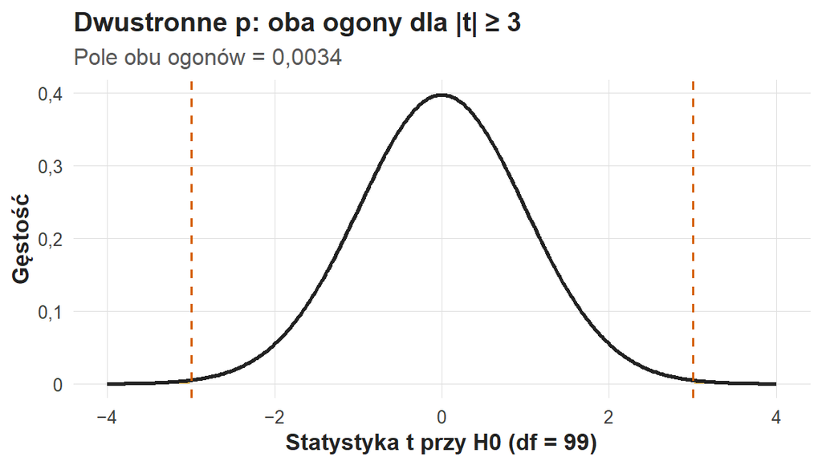

Dwustronne p: oba ogony dla |t| ≥ 3. Oś pozioma: statystyka t przy H0 z 99 stopniami swobody; oś pionowa: gęstość. Krzywa jest symetryczna wokół zera; wyróżnione obszary na lewo od −3 i na prawo od 3 mają łączne pole 0,0034, równe dwustronnemu p.

Odczyt pełnym zdaniem brzmi: „Przy hipotezie średniej równej 3 i założeniach testu wynik o takiej lub większej bezwzględnej wartości t zdarzałby się w 0,34% prób”. [Stanowisko ASA z 2016 roku](https://doi.org/10.1080/00031305.2016.1154108) opisuje wartość p jako jeden z elementów argumentu naukowego; raport zapisuje efekt, niepewność i warunki analizy obok wyniku testu.

# Efekt naturalny, standaryzowany i praktyczny

W przykładzie efekt naturalny wynosi 0,24 punktu. Efekt standaryzowany jednej próby i jego relacja do statystyki t mają postać:

$$d=\frac{\bar{x}-\mu_0}{s}=\frac{0{,}24}{0{,}80}=0{,}30,\qquad t=d\sqrt{n}=0{,}30\cdot10=3 .$$

Mianownikiem $d$ jest SD osób (0,80 punktu), mianownikiem $t$ — SE (0,08 punktu); dlatego $t=3$ i $d=0{,}30$ są jednocześnie poprawne. Standaryzacja wyraża różnicę w jednostkach SD osób, więc $d$ zależy od rozrzutu: różnica 0,24 punktu daje $d=0{,}30$ przy SD = 0,80 i $d=0{,}48$ przy SD = 0,50.

Znaczenie praktyczne wynika z kryterium decyzji instytucji, np. z najmniejszej różnicy uzasadniającej zmianę katalogu, z zauważalnej zmiany wykonania albo z trafności interpretacji narzędzia. Próg praktyczny ustala się przed analizą; próg zaproponowany po obejrzeniu wyniku raportuje się jako eksploracyjny. W projekcie dydaktycznym umowne progi mają nazwę progów umownych.

# Przykład drugi: czas z małej próby

W innej demonstracji N = 16 osób, średni czas 11,2 minuty, SD = 6 minut, a odniesienie wynosi 10 minut. Estymata różnicy to 1,2 minuty, SE równa się $6/\sqrt{16}=1{,}5$ minuty, a $t=0{,}8$.

Tabela „Przykład czasu: składniki obliczenia” podaje N = 16, SE = 1,5 minuty, t = 0,80, df = 15, p = 0,4362 i przedział różnicy [−1,997; 4,397] minuty. Rachunek opiera się na podanych statystykach opisowych; ocena skośności i pojedynczych długich prób wymaga surowych danych.

Przykład czasu: składniki obliczenia

| Wielkość | Wartość | Jednostka |
| --- | --- | --- |
| Liczba osób N | 16 | osoby |
| Średnia | 11,20 | minuty |
| SD osób | 6,00 | minuty |
| SE średniej | 1,500 | minuty |
| Wartość odniesienia | 10,00 | minuty |
| Różnica od odniesienia | 1,20 | minuty |
| 95% CI średniej | [8,003; 14,397] | minuty |
| 95% CI różnicy | [−1,997; 4,397] | minuty |
| Statystyka t | 0,80 | bez jednostki |
| Stopnie swobody df | 15 | bez jednostki |
| Wartość p (dwustronna) | 0,4362 | prawdopodobieństwo |
| Standaryzowana różnica d | 0,20 | SD osób |

Przedział [−2,00; 4,40] obejmuje zero i różnice do 4,4 minuty, więc dane są zgodne zarówno z równością średniej i odniesienia, jak i z różnicą istotną dla usługi. Przykład czasu z 16 osobami ilustruje wynik nieprecyzyjny: raport podaje oszacowanie 1,2 minuty i przedział od −2,0 do 4,4 minuty. Wykazanie bliskości do celu wymaga tolerancji $\pm\delta$ ustalonej przed badaniem i testu równoważności (TOST, rozszerzenie): przedział 90% różnicy leży wtedy w całości w $[-\delta;\,\delta]$.

# Alfa, błędy i moc: własności procedury

Poziom $\alpha$ ustala się przed oceną wyniku. Trzy prawdopodobieństwa opisują procedurę testu:

$$\alpha=P(\text{odrzucenie }H_0\mid H_0),\qquad \beta=P(\text{pozostawienie }H_0\mid H_1),\qquad \text{moc}=1-\beta .$$

Poziom $\alpha$ opisuje częstość błędnych odrzuceń w długiej serii testów przy prawdziwej $H_0$. Tabela „Decyzje testu i ich prawdopodobieństwa” zestawia cztery sytuacje.

Decyzje testu i ich prawdopodobieństwa

| Stan modelowy | Pozostawienie H0 | Odrzucenie H0 |
| --- | --- | --- |
| H0 prawdziwa | Decyzja zgodna z H0, prawdopodobieństwo $1-\alpha$ | Błąd I rodzaju, prawdopodobieństwo $\alpha$ |
| Określona alternatywa prawdziwa | Błąd II rodzaju, prawdopodobieństwo $\beta$ | Wykrycie alternatywy, moc $1-\beta$ |

Wykres „Błędy decyzji przy d = 0,30 i n = 100” zestawia rozkład statystyki t przy $H_0$ (środek 0) z rozkładem przy alternatywie $d=0{,}30$ i $n=100$ (środek $d\sqrt{n}=3$).

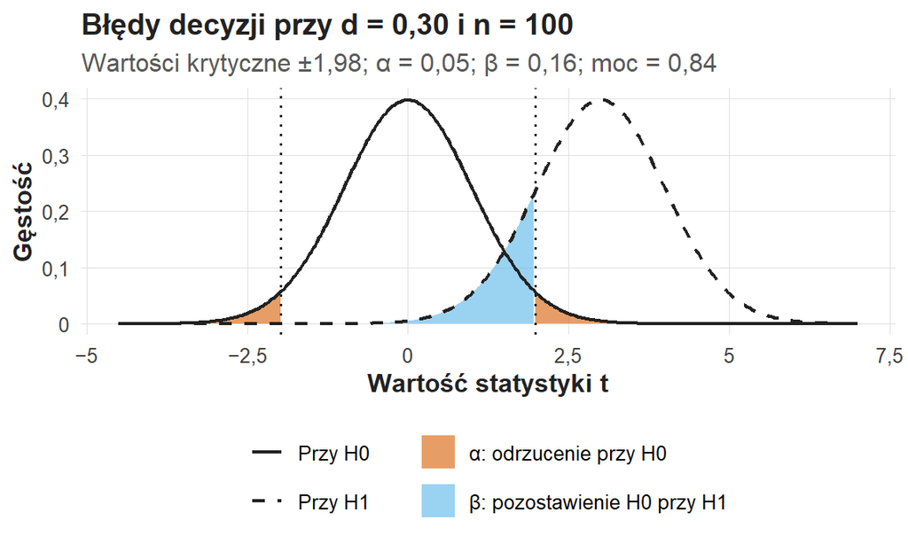

Błędy decyzji przy d = 0,30 i n = 100. Oś pozioma: wartość statystyki t; oś pionowa: gęstość. Krzywa ciągła (przy H0) ma środek w zerze, krzywa przerywana (przy H1) w 3. Linie kropkowane przy ±1,98 to wartości krytyczne. Pole α = 0,05 leży w ogonach krzywej H0 poza wartościami krytycznymi; pole β = 0,16 to część krzywej H1 między wartościami krytycznymi, więc moc wynosi 0,84.

Moc zależy od czterech wielkości: efektu, zmienności, $n$ i poziomu $\alpha$. Przybliżenie normalne mocy testu dwustronnego ma postać

$$1-\beta\approx\Phi\!\left(|d|\sqrt{n}-z_{1-\alpha/2}\right)=\Phi(3-1{,}96)=0{,}85 ;$$

dokładne obliczenie rozkładem t daje 0,84. Wykres „Moc testu t jednej próby” przedstawia moc jako funkcję liczebności dla trzech efektów.

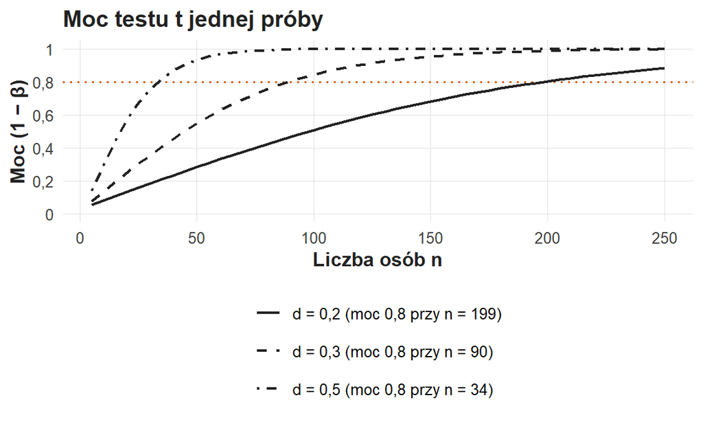

Większa próba zwiększa moc i zwęża przedział; błąd systematyczny pomiaru pozostaje. Liczebność planuje się także z wymaganej precyzji: połowa szerokości przedziału $E$ przy SD $s$ wymaga

$$n=\left(\frac{z_{0{,}975}\,s}{E}\right)^2=\left(\frac{1{,}96\cdot0{,}8}{0{,}1}\right)^2\approx246$$

osób dla indeksu o SD 0,8 punktu i połowie szerokości 0,1 punktu.

## Wiele prób znalezienia jednego wyniku

Wykonanie $m$ niezależnych testów przy prawdziwych hipotezach zerowych i poziomie 0,05 daje prawdopodobieństwo co najmniej jednego odrzucenia $1-0{,}95^{m}$: 0,23 dla 5 testów, 0,40 dla 10 i 0,64 dla 20.

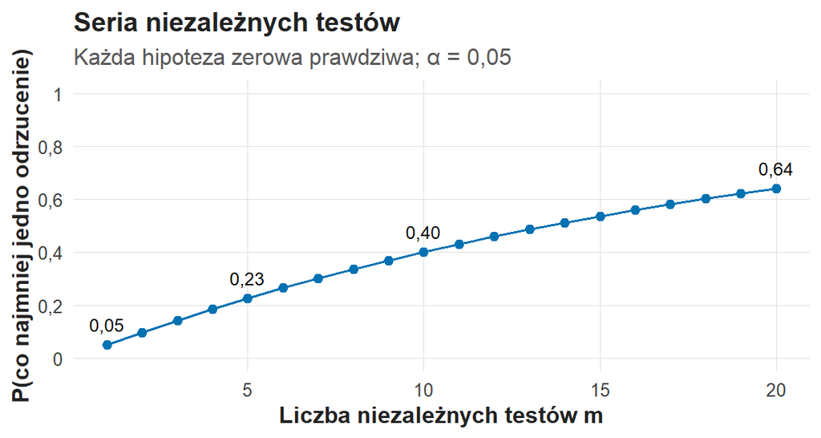

Seria niezależnych testów, każda hipoteza zerowa prawdziwa, α = 0,05. Oś pozioma: liczba testów m od 1 do 20; oś pionowa: prawdopodobieństwo co najmniej jednego odrzucenia. Krzywa rośnie od 0,05 przy jednym teście przez 0,23 przy pięciu i 0,40 przy dziesięciu do 0,64 przy dwudziestu.

Liczba 64% dotyczy 20 niezależnych testów; przy testach zależnych prawdopodobieństwo jest mniejsze, a mechanizm selektywnego wyboru ten sam. Szukanie wielu podziałów grup, progów czasu i wariantów braków, a potem raportowanie najniższego p zmienia procedurę, więc raport opisuje wszystkie wykonane warianty analizy i oddziela pytania zaplanowane od eksploracji.

Wyniki $p=0{,}049$ i $p=0{,}051$ niosą niemal tę samą informację, choć reguła $\alpha=0{,}05$ przypisuje im różne decyzje. Porównanie efektów dwóch badań wymaga testu różnicy efektów.

# Losowanie komputerowe ma dwa zadania

Dwa zadania losowania komputerowego

| Pytanie | Procedura | Wynik procedury |
| --- | --- | --- |
| Jak zmieniałaby się estymata? | Bootstrap obserwacji z powtórzeniami | Przybliżenie niepewności estymatora |
| Jak skrajna jest statystyka przy modelu zerowym? | Dopuszczalne przestawienia lub zmiany znaków | Rozkład odniesienia testu |

Bootstrap odtwarza zmienność estymatora wokół informacji z próby, a test przestawień — rozkład statystyki w świecie hipotezy zerowej. Przykład bootstrapu i przykład zmiany znaków dotyczą jednej próby 40 osób o średniej 9,43 minuty.

## Bootstrap: próba jako przybliżenie populacji

Podstawowy bootstrap nieparametryczny losuje z $n$ obserwacji $n$ elementów z powtórzeniami i ponownie liczy statystykę:

$$x^*_1,\dots,x^*_n\ \text{losowane z}\ \{x_1,\dots,x_n\},\qquad \bar{x}^*_b\ \text{dla}\ b=1,\dots,B,\qquad SE_{\mathrm{boot}}=\mathrm{SD}(\bar{x}^*_b),$$

a przedział percentylowy to $[Q^*(0{,}025);\ Q^*(0{,}975)]$, kwantyle rozkładu bootstrapowego. Jedna osoba pojawia się w próbie bootstrapowej kilka razy, inna wcale. Podstawy metody opisał [Efron (1979)](https://doi.org/10.1214/aos/1176344552).

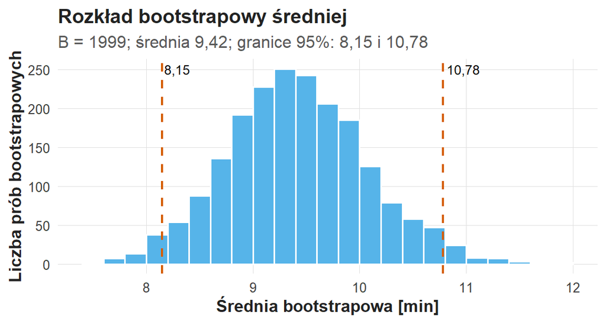

Rozkład bootstrapowy średniej jednej próby 40 osób, B = 1999. Oś pozioma: średnia bootstrapowa w minutach; oś pionowa: liczba prób bootstrapowych. Histogram ma środek przy 9,42 minuty; linie przerywane przy 8,15 i 10,78 minuty to granice 2,5% i 97,5%, czyli 95% przedział percentylowy.

$SE_{\mathrm{boot}}$ wynosi 0,66 minuty, a przedział percentylowy [8,15; 10,78] leży blisko przedziału t [8,06; 10,80]. Bootstrap korzysta wyłącznie z wartości obecnych w próbie, więc ilość informacji wyznacza $n$. Przy małym $n$, skrajnych rozkładach i parametrach na granicy prosty wariant daje pokrycie niższe od nominalnego. Dla par i klastrów losuje się całe pary lub klastry. Liczba $B$ wyznacza dokładność przybliżenia komputerowego, a wielkość próby pozostaje równa $n$; raport podaje $B$ i $n$ osobno.

## Zmiana znaków: konkretny model zerowy

Test zmian znaków dla jednej próby analizuje odchylenia $d_i=x_i-\mu_0$. Każde odchylenie mnoży się niezależnie przez losowy znak $\varepsilon_i\in\{-1,+1\}$ i liczy średnią:

$$T^*_b=\frac{1}{n}\sum_{i=1}^{n}\varepsilon_i d_i,\qquad \text{liczba możliwych układów znaków}=2^{n}.$$

Test zakłada niezależność i symetrię rozkładu odchyleń wokół zera przy $H_0$; skośne czasy o średniej równej odniesieniu łamią symetrię. Warunki przestawień omawiają [Winkler i współautorzy (2014)](https://pmc.ncbi.nlm.nih.gov/articles/PMC4010955/). W teście dwóch grup przestawia się etykiety grup, gdy uzasadniona jest wymienialność: przy $H_0$ każda permutacja etykiet jest równie prawdopodobna. Obserwacje jednej osoby przestawia się razem.

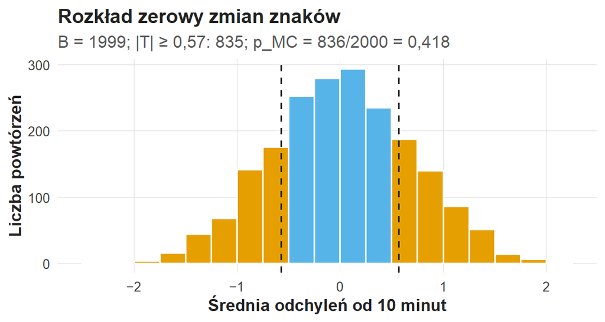

Rozkład zerowy zmian znaków dla próby 40 osób i odniesienia 10 minut, B = 1999. Oś pozioma: średnia odchyleń od 10 minut; oś pionowa: liczba powtórzeń. Histogram jest symetryczny wokół zera i leży od −2,30 do 2,04. Linie przerywane przy −0,57 i 0,57 oznaczają obserwowaną wartość i jej odbicie; wyróżnione słupki zawierają wartości leżące na liniach lub dalej, a 835 z 1999 wartości spełnia |T| ≥ 0,57.

Obserwowana średnia odchyleń $T_{\mathrm{obs}}=−0,57$ minuty leży w środkowej części rozkładu zerowego. Przy $B$ losowych przestawieniach kurs stosuje:

$$p_{\mathrm{MC}}=\frac{1+\#\{|T_b^*|\geq|T_{\mathrm{obs}}|\}}{B+1}=\frac{1+835}{1999+1}=0,418 .$$

Symbol $\#$ oznacza liczbę powtórzeń spełniających warunek, a znak $\geq$ obejmuje remisy. Dla $B=1999$ i 39 wyników co najmniej tak skrajnych otrzymujemy $40/2000=0{,}02$; najmniejsza wartość osiągalna przy $B=1999$ to $1/2000=0{,}0005$. Jedynka w liczniku i mianowniku zapewnia dodatnie $p_{\mathrm{MC}}$; poprawność testu zależy od schematu przestawień. Znaczenie poprawnego obliczania losowanych p omawiają [Phipson i Smyth (2010)](https://pubmed.ncbi.nlm.nih.gov/21044043/). Test t tej samej próby daje $t=-0{,}84$ i $p=0{,}404$.

$B$ wpływa na rozdzielczość i losową dokładność obliczenia. Błąd Monte Carlo wartości p wynosi

$$SE(p_{\mathrm{MC}})\approx\sqrt{\frac{p(1-p)}{B}}:\qquad \sqrt{\frac{0{,}05\cdot0{,}95}{1999}}=0{,}005 ,$$

więc przy prawdziwym $p$ bliskim 0,05 dwa uruchomienia z różnymi ziarnami mogą dać wyniki po dwóch stronach progu. Ziarno generatora ustala się przed analizą i raportuje; ziarno zapewnia odtwarzalność obliczenia.

# Zgodność testu i przedziału

W dwustronnym teście t na poziomie 0,05 i odpowiadającym mu dwustronnym przedziale t 95% wykluczenie wartości zerowej z przedziału odpowiada odrzuceniu $H_0$. Dla średniej sprawdza się $\mu_0$, a dla różnicy — zero. Zgodność dotyczy pary: dwustronny test t na poziomie 0,05 i przedział t 95%.

Test t i percentylowy przedział bootstrapowy opierają się na różnych założeniach i przybliżeniach, więc przy wynikach bliskich progu ich decyzje mogą się różnić; raport podaje oba wyniki i wyjaśnia różnicę. Ćwiczenie C05 (Niepewność estymaty: przedział, bootstrap i test jednej próby) przedstawia klasyczny przedział i bootstrap osobno i opisuje parametr objęty każdą parą granic. Zgodność wniosków opisuje dwie konkretne analizy.

# Czytanie krótkiego raportu

Raport pierwszego przykładu zaczyna się tak: „W hipotetycznej próbie 100 osób średni indeks wyniósł 3,24 punktu (SD = 0,80). Różnica względem umownego odniesienia 3 wyniosła 0,24 punktu, 95% CI [0,081; 0,399]. W teście t uzyskano t(99) = 3,00, p = 0,0034; standaryzowana różnica d = 0,30”.

Drugi akapit opisuje sens: „Odpowiedzi były przeciętnie przesunięte w stronę korzystnej oceny katalogu. Indeks opisuje deklarowaną użyteczność katalogu; wniosek o skutku zmiany interfejsu wymaga eksperymentu, a uogólnienie — uzasadnienia doboru próby i jakości pomiaru”.

Raport drugiego przykładu zachowuje szerokość niepewności: „Oszacowana różnica czasu wyniosła 1,2 minuty, a przedział od −2,0 do 4,4 minuty obejmuje zarówno brak różnicy, jak i kilkuminutowe wydłużenie wyszukiwania”.

## Popraw zdanie

Każde z trzech zdań zawiera błąd odczytu; poprawna wersja stoi po strzałce.

- „Szansa, że H0 jest prawdziwa, wynosi 0,34%” → „Przy prawdziwej H0 i założeniach testu wynik co najmniej tak skrajny zdarzałby się w 0,34% prób”.
- „99,66% użytkowników ocenia katalog pozytywnie” → „Średni indeks 3,24 przewyższa środek skali o 0,24 punktu, 95% CI [0,081; 0,399]”.
- „Przedział 95% [8,06; 10,80] obejmuje czasy 95% użytkowników” → „Przedział 95% [8,06; 10,80] dotyczy średniego czasu; środkowe 95% czasów leży od 4,38 do 19,86 minuty”.

## Sprawdzenie rozumienia

W akapicie raportu odszukaj kolejno estymandę, N, efekt, jednostkę, przedział, statystykę, df i p. Rozróżnij liczbę opisującą zróżnicowanie osób od liczby opisującej niepewność średniej. Sprawdź, czy ograniczenie nazywa cechę projektu: dobór próby, pomiar albo założenie testu. Ćwiczenie służy samodzielnej kontroli odczytu.

Odczyt p jako szansy prawdziwości H0 poprawia wykres „Dwustronne p: oba ogony dla |t| ≥ 3” (rozkład t przy $H_0$). Odczyt przedziału ufności jako zakresu czasów 95% użytkowników poprawiają wykresy „Rozrzut osób i rozrzut średnich” oraz „Trzy przedziały jednej próby 40 osób”. Nazwanie t wielkością efektu w punktach poprawia wzór $t=d\sqrt{n}$.

# Most do ćwiczenia C05 i dalszych analiz

Ćwiczenie C05 stosuje pojęcia wykładu W03 do indeksu S02 i do wariantu zadania. Wykład W04 (Porównania grup i zależności kategorii) i wykład W05 (Korelacja, regresja i raport ilościowy) zmieniają estymandę: różnica grup, związek kategorii, korelacja, nachylenie. Obowiązek określenia wielkości, jednostki, danych, niepewności i warunków pozostaje ten sam.

Wykonanie testu jest krótką częścią analizy. Dłuższa praca polega na ustaleniu, czy pytanie testu jest pytaniem badawczym projektu; w zarządzaniu informacją ustalenie pytania odróżnia obliczoną statystykę od użytecznego argumentu o działaniu usługi.

# Literatura do dalszej pracy

- Wasserstein, R.L., Lazar, N.A. (2016). *The ASA’s Statement on p-Values: Context, Process, and Purpose*. The American Statistician, 70(2), 129–133. [DOI](https://doi.org/10.1080/00031305.2016.1154108).
- Efron, B. (1979). *Bootstrap Methods: Another Look at the Jackknife*. The Annals of Statistics, 7(1), 1–26. [DOI](https://doi.org/10.1214/aos/1176344552).
- Winkler, A.M., Ridgway, G.R., Webster, M.A., Smith, S.M., Nichols, T.E. (2014). *Permutation inference for the general linear model*. NeuroImage, 92, 381–397. [Pełny tekst](https://pmc.ncbi.nlm.nih.gov/articles/PMC4010955/).
- Phipson, B., Smyth, G.K. (2010). *Permutation P-values Should Never Be Zero: Calculating Exact P-values When Permutations Are Randomly Drawn*. Statistical Applications in Genetics and Molecular Biology, 9(1). [PubMed](https://pubmed.ncbi.nlm.nih.gov/21044043/).

Przykłady liczbowe i symulacje wykładu są dydaktyczne; wyniki cytowanych prac zawierają ich publikacje.